# Sorrisos e portais

## Um experimento com sorrisos

*Dados utilizados:*

```r
sorriso = read_csv(here::here("data/leniency.csv"),
                 col_types = "cdc")

glimpse(sorriso)
```

```
## Rows: 136
## Columns: 3
## $ smile      <chr> "false smile", "false smile", "false smile", "false smile",~
## $ leniency   <dbl> 2.5, 5.5, 6.5, 3.5, 3.0, 3.5, 6.0, 5.0, 4.0, 4.5, 5.0, 5.5,~
## $ with_smile <chr> "yes", "yes", "yes", "yes", "yes", "yes", "yes", "yes", "ye~
```

*Distribuição dos dados das fotos com e sem sorriso a partir dos valores de leniência:*

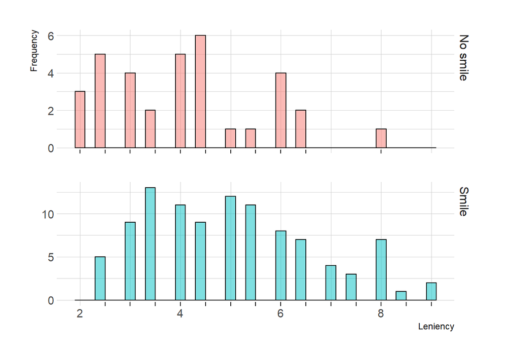

```r
sorriso %>%
    mutate(sorriu = if_else(with_smile == "yes", "Smile", "No smile")) %>%
    ggplot(aes(x = leniency, fill = with_smile)) +
    geom_histogram(binwidth = .2, alpha = .5, color = "black") +
    geom_rug() +
    facet_grid(sorriu ~ ., scales = "free_y") +
    theme(legend.position = "None") +
    labs(
        y = "Frequency",
        x = "Leniency"
    )
```

### Quanto ter a pessoa sorrindo na foto (independente do sorriso) causa de mudança no julgamento das pessoas em geral? Quão relevante é essa mudança?

```r
s <- function(d, i) {
    sumarizado = d[i,] %>%
        summarise(do_grupo = sum(with_smile == "yes") / n())

    sumarizado %>%
      pull(do_grupo)
}

booted <- boot(data = sorriso,
               statistic = s,
               R = 2000)

estimado = tidy(booted,
                conf.level = .95,
                conf.method = "basic",
                conf.int = TRUE)
```

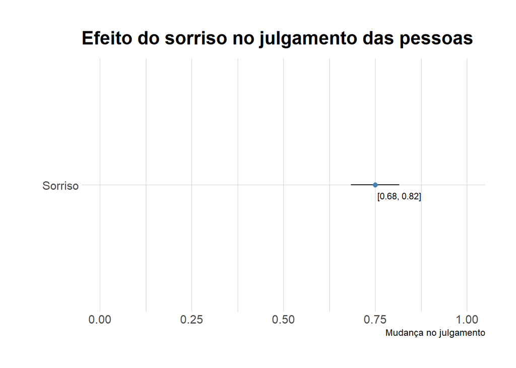

```r
estimado %>%
    ggplot(aes(
        ymin = conf.low,
        y = statistic,
        ymax = conf.high,
        x = "Sorriso"
    )) +
    geom_linerange() +
    geom_point(color = "steelblue", size = 2) +
    geom_text(
        aes(
            y = conf.high,
            label = str_glue("[{round(conf.low, 2)}, {round(conf.high, 2)}]")
        ),
        size = 3,
        nudge_x = -.05,
        show.legend = F
    )  +
    scale_y_continuous(limits = c(0, 1)) +
    labs(
        title = "Efeito do sorriso no julgamento das pessoas",
        x = "", y = "Mudança no julgamento") +
    coord_flip()
```

### Como se comparam os efeitos dos diferentes sorrisos no julgamento das pessoas?

```r
false_smile = sorriso %>%
        filter(smile == "false smile")

felt_smile = sorriso %>%
        filter(smile == "felt smile")

miserable_smile = sorriso %>%
        filter(smile == "miserable smile")

no_smile = sorriso %>%
        filter(smile == "no smile (control)")
```

```r
s1 <- function(d, i) {
    a = d[i,] %>%
        filter(smile == "false smile") %>%
        summarise(do_grupo = mean(leniency)) %>%
        pull(do_grupo)

    b = d[i,] %>%
        filter(smile == "no smile (control)") %>%
        summarise(do_grupo = mean(leniency)) %>%
        pull(do_grupo)

    a - b
}

s2 <- function(d, i) {
    a = d[i,] %>%
        filter(smile == "felt smile") %>%
        summarise(do_grupo = mean(leniency)) %>%
        pull(do_grupo)

    b = d[i,] %>%
        filter(smile == "no smile (control)") %>%
        summarise(do_grupo = mean(leniency)) %>%
        pull(do_grupo)

    a - b
}

s3 <- function(d, i) {
    a = d[i,] %>%
        filter(smile == "miserable smile") %>%
        summarise(do_grupo = mean(leniency)) %>%
        pull(do_grupo)

    b = d[i,] %>%
        filter(smile == "no smile (control)") %>%
        summarise(do_grupo = mean(leniency)) %>%
        pull(do_grupo)

    a - b
}
```

```r
cifalse = boot(data = sorriso,
                   statistic = s1,
                   R = 2000) %>%
    tidy(conf.level = .95,
         conf.method = "bca",
         conf.int = TRUE)

cifelt = boot(data = sorriso,
                   statistic = s2,
                   R = 2000) %>%
    tidy(conf.level = .95,
         conf.method = "bca",
         conf.int = TRUE)


cimiserable = boot(sorriso,
                   statistic = s3,
                   R = 2000) %>%
    tidy(conf.level = .95,
         conf.method = "bca",
         conf.int = TRUE)
```

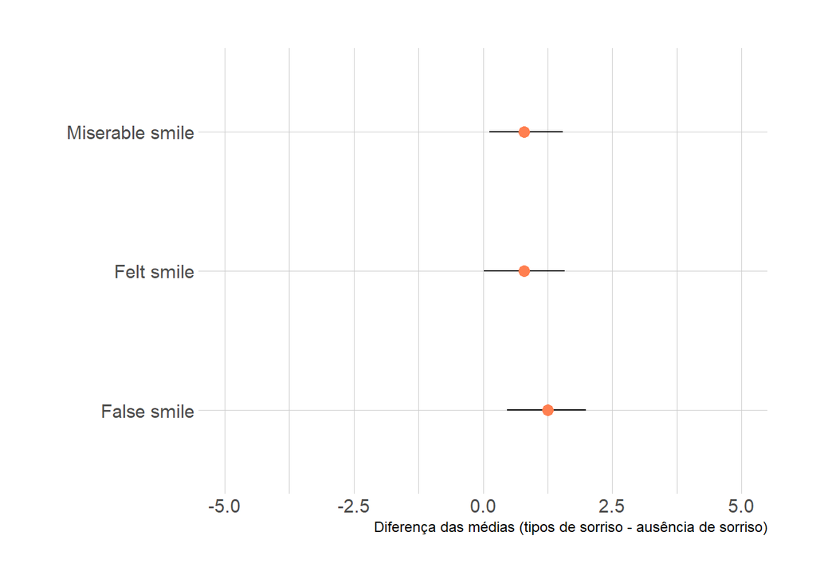

```r
cis = bind_rows(
  "False smile" = cifalse,
  "Felt smile" = cifelt,
  "Miserable smile" = cimiserable,
  .id = "grupo"
)

cis %>%
  ggplot(aes(
            ymin = conf.low,
            y = statistic,
            ymax = conf.high,
            x = grupo
        )) +
        geom_linerange() +
        geom_point(color = "coral", size = 3) +
        scale_y_continuous(limits = c(-5, 5)) +
        labs(x = "", y = "Diferença das médias (tipos de sorriso - ausência de sorriso)") +
        coord_flip()
```

**Para o Miserable Smile a diferença das médias foi de 0.79 com variação entre 0.08 e 1.47 e para o Felt Smile a diferença das médias foi de 0.79, com variação entre 0.04 e 1.57, os dois apresentam efeitos semelhantes e de relevância baixa à média. Já para o False Smile a diferença das médias foi de 1.25, com variação entre 0.44 e 2.02, apresentando um efeito relevante de médio à alto. Considerando a variação da diferença das médias dos tipos de sorriso, o sorriso que causa um maior efeito no julgamento das pessoas é, provavelmente, o False Smile.**

## Tempo de carregamento de portais

*Dados utilizados:*

```r
tempo = read_csv(here::here("data/requests-portais.csv"),
                 col_types = "cd")

glimpse(tempo)
```

```
## Rows: 120
## Columns: 2
## $ site <chr> "g1", "g1", "g1", "g1", "g1", "g1", "g1", "g1", "g1", "g1", "g1",~
## $ time <dbl> 1.600459, 1.471800, 1.398192, 1.380360, 1.386828, 1.529101, 1.393~
```

```r
g1 = tempo %>%
        filter(site == "g1")

folha = tempo %>%
        filter(site == "folha")

terra = tempo %>%
        filter(site == "terra")

uol = tempo %>%
        filter(site == "uol")
```

### Considerando a média de tempo para responder, qual você estima que é o portal mais rápido em geral (ou seja, na população de todas as requisições que originou nossa amostra)?

```r
theta <- function(d, i) {
    d[i] %>%
        mean(na.rm = T)
}
```

```r
cig1 = boot(data = (g1$time),
                   statistic = theta,
                   R = 2000) %>%
    tidy(conf.level = .95,
         conf.method = "bca",
         conf.int = TRUE)

cifolha = boot(data = folha$time,
                   statistic = theta,
                   R = 2000) %>%
    tidy(conf.level = .95,
         conf.method = "bca",
         conf.int = TRUE)


citerra = boot(data = terra$time,
                   statistic = theta,
                   R = 2000) %>%
    tidy(conf.level = .95,
         conf.method = "bca",
         conf.int = TRUE)


ciuol = boot(data = uol$time,
                   statistic = theta,
                   R = 2000) %>%
    tidy(conf.level = .95,
         conf.method = "bca",
         conf.int = TRUE)
```

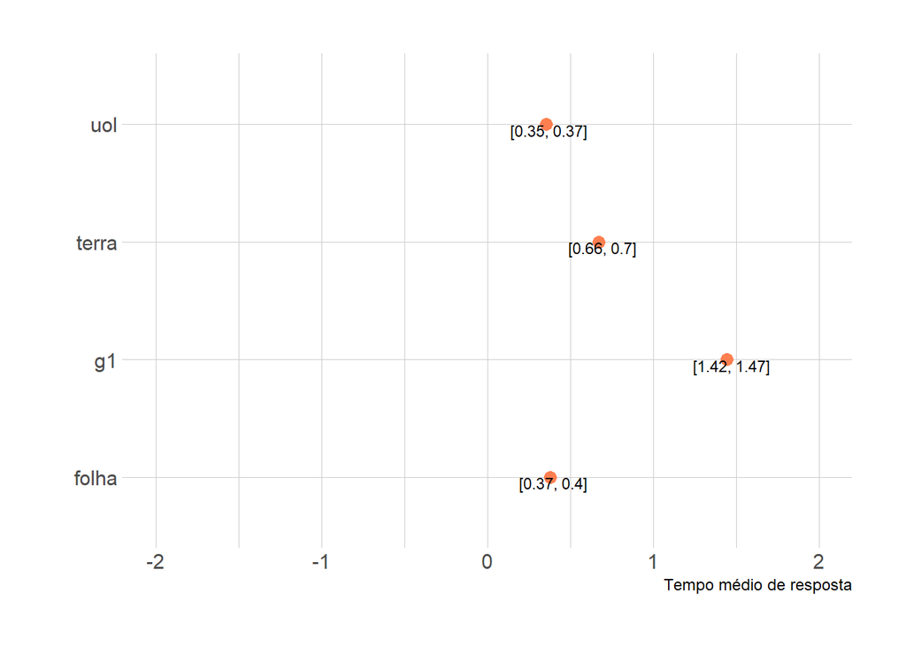

```r
cis = bind_rows(
  "g1" = cig1,
  "folha" = cifolha,
  "terra" = citerra,
  "uol" = ciuol,
  .id = "grupo"
)

cis %>%
  ggplot(aes(
            x = grupo,
            ymin = conf.low,
            ymax = conf.high,
            y = statistic,
        )) +
        geom_linerange() +
        geom_point(color = "coral", size = 3) +
        geom_text(
            aes(
                y = conf.high,
                label = str_glue("[{round(conf.low, 2)}, {round(conf.high, 2)}]")
            ),
            size = 3,
            nudge_x = -.05,
            show.legend = F
        )  +
        scale_y_continuous(limits = c(-2, 2)) +
        labs(x = "", y = "Tempo médio de resposta") +
        coord_flip()
```

Qual o tamanho da diferença entre o(s) mais rápido(s) e os mais lentos?

```r
s1 <- function(d, i) {
    a = d[i,] %>%
        filter(site == "g1") %>%
        summarise(do_grupo = mean(time)) %>%
        pull(do_grupo)

    b = d[i,] %>%
        filter(site == "uol") %>%
        summarise(do_grupo = mean(time)) %>%
        pull(do_grupo)

    a - b
}
s2 <- function(d, i) {
    a = d[i,] %>%
        filter(site == "folha") %>%
        summarise(do_grupo = mean(time)) %>%
        pull(do_grupo)

    b = d[i,] %>%
        filter(site == "uol") %>%
        summarise(do_grupo = mean(time)) %>%
        pull(do_grupo)

    a - b
}

s3 <- function(d, i) {
    a = d[i,] %>%
        filter(site == "terra") %>%
        summarise(do_grupo = mean(time)) %>%
        pull(do_grupo)

    b = d[i,] %>%
        filter(site == "uol") %>%
        summarise(do_grupo = mean(time)) %>%
        pull(do_grupo)

    a - b
}
```

```r
booted1 <- boot(data = tempo,
               statistic = s1,
               R = 2000)

estimado1 = tidy(booted1,
                conf.level = .95,
                conf.method = "bca",
                conf.int = TRUE)

booted2 <- boot(data = tempo,
               statistic = s2,
               R = 2000)

estimado2 = tidy(booted2,
                conf.level = .95,
                conf.method = "bca",
                conf.int = TRUE)

booted3 <- boot(data = tempo,
               statistic = s3,
               R = 2000)

estimado3 = tidy(booted3,
                conf.level = .95,
                conf.method = "bca",
                conf.int = TRUE)
```

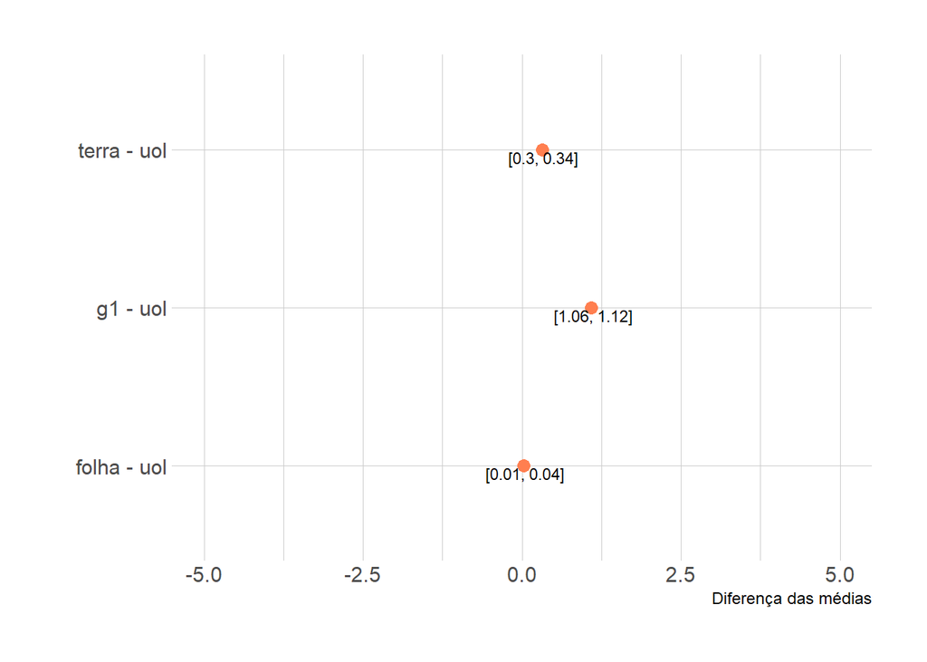

```r
cis = bind_rows(
  "g1 - uol" = estimado1,
  "folha - uol" = estimado2,
  "terra - uol" = estimado3,
  .id = "grupo"
)


cis %>%
  ggplot(aes(
            ymin = conf.low,
            y = statistic,
            ymax = conf.high,
            x = grupo
        )) +
        geom_linerange() +
        geom_point(color = "coral", size = 3) +
        geom_text(
            aes(
                y = conf.high,
                label = str_glue("[{round(conf.low, 2)}, {round(conf.high, 2)}]")
            ),
            size = 3,
            nudge_x = -.05,
            show.legend = F
        )  +
        scale_y_continuous(limits = c(-5, 5)) +
        labs(x = "", y = "Diferença das médias") +
        coord_flip()
```

**Para o site G1 a diferença das médias foi de 1.08 com variação entre 1.06 e 1.12, apresentando a maior diferença entre os portais. Já para o Folha a diferença foi de 0.023 com variação entre 0.01 e 0.04, apresentando a menor diferença, e para o Terra a diferença foi de 0.31, com variação entre 0.3 e 0.34, a segunda menor diferença. Considerando a variação da diferença do tempo de resposta dos portais, é provável que o UOL e o Folha possuam valores de tempo de resposta semelhantes.**

### Suas conclusões mudam se em vez da média você considerar o 75-percentil dos tempos de resposta?

```r
s11 <- function(d, i) {
    a = d[i,] %>%
        filter(site == "g1") %>%
        summarise(do_grupo =  quantile(time, probs = 0.75)) %>%
        pull(do_grupo)

    b = d[i,] %>%
        filter(site == "uol") %>%
        summarise(do_grupo = quantile(time, probs = 0.75)) %>%
        pull(do_grupo)

    a - b
}
s22 <- function(d, i) {
    a = d[i,] %>%
        filter(site == "folha") %>%
        summarise(do_grupo = quantile(time, probs = 0.75)) %>%
        pull(do_grupo)

    b = d[i,] %>%
        filter(site == "uol") %>%
        summarise(do_grupo = quantile(time, probs = 0.75)) %>%
        pull(do_grupo)

    a - b
}

s33 <- function(d, i) {
    a = d[i,] %>%
        filter(site == "terra") %>%
        summarise(do_grupo = quantile(time, probs = 0.75)) %>%
        pull(do_grupo)

    b = d[i,] %>%
        filter(site == "uol") %>%
        summarise(do_grupo = quantile(time, probs = 0.75)) %>%
        pull(do_grupo)

    a - b
}
```

```r
booted11 <- boot(data = tempo,
               statistic = s11,
               R = 2000)

estimado11 = tidy(booted11,
                conf.level = .95,
                conf.method = "bca",
                conf.int = TRUE)

booted22 <- boot(data = tempo,
               statistic = s22,
               R = 2000)

estimado22 = tidy(booted22,
                conf.level = .95,
                conf.method = "bca",
                conf.int = TRUE)

booted33 <- boot(data = tempo,
               statistic = s33,
               R = 2000)

estimado33 = tidy(booted33,
                conf.level = .95,
                conf.method = "bca",
                conf.int = TRUE)
```

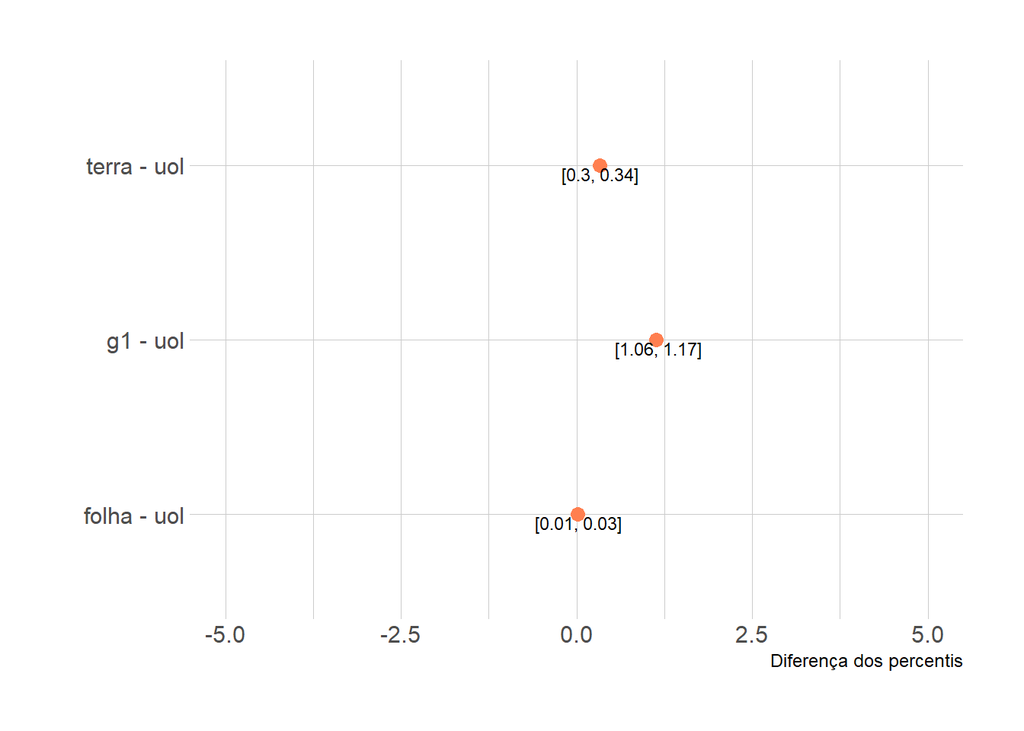

```r
cis = bind_rows(
  "g1 - uol" = estimado11,
  "folha - uol" = estimado22,
  "terra - uol" = estimado33,
  .id = "grupo"
)


cis %>%
  ggplot(aes(
            ymin = conf.low,
            y = statistic,
            ymax = conf.high,
            x = grupo
        )) +
        geom_linerange() +
        geom_point(color = "coral", size = 3) +
        geom_text(
            aes(
                y = conf.high,
                label = str_glue("[{round(conf.low, 2)}, {round(conf.high, 2)}]")
            ),
            size = 3,
            nudge_x = -.05,
            show.legend = F
        )  +
        scale_y_continuous(limits = c(-5, 5)) +
        labs(x = "", y = "Diferença dos percentis") +
        coord_flip()
```

**A diferença utilizando o 75-percentil foi mínima, com alteração apenas nos valores dos intervalos da diferença do G1, que foi de 1.12 para 1.17, e para o Folha que foi de 0.04 para 0.03 nos maiores valores dos intervalos, sendo o site UOL o que apresentou a maior velocidade no tempo de resposta seguido pelo Folha. No geral, as conclusões permaneceram praticamente as mesmas usando tanto a média quanto o 75-percentil.**